# Figures and Tables

Arthur M. Albuquerque

June 27, 2022

# Figure 1

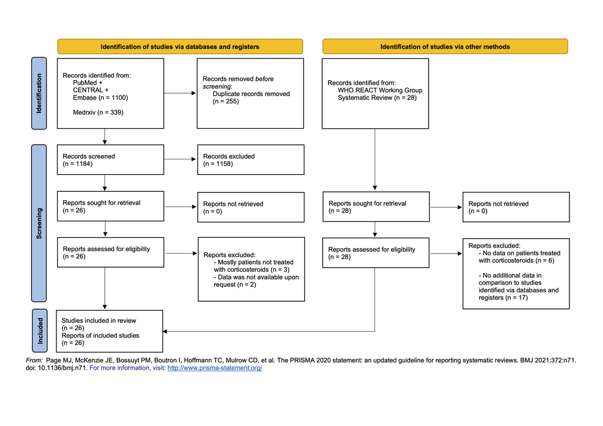

PRISMA 2020 Flow Diagram

# Table 1

Overall characteristics of included RCTs

| Study | Article Type | Dose | Drug Regimen | Control Type | Follow-up Length<sup>1</sup> | Control Treatment Number of Sites | Control Treatment Age<sup>2</sup> | Control Treatment Male<sup>3</sup> | Control Treatment Time since Symptom Onset<sup>2</sup> | Control Treatment Lab Confirmed COVID-19<sup>3</sup> | Control Treatment Simple Oxygen Only<sup>3</sup> | Control Treatment Noninvasive Ventilation<sup>3</sup> | Experimental Treatment Invasive Mechanical Ventilation<sup>3</sup> | Experimental Treatment Age <sup>2</sup> | Experimental Treatment Male <sup>3</sup> | Experimental Treatment Time since Symptom Onset <sup>2</sup> | Experimental Treatment Lab Confirmed COVID-19 <sup>3</sup> | Experimental Treatment Simple Oxygen Only <sup>3</sup> | Experimental Treatment Noninvasive Ventilation <sup>3</sup> | Experimental Treatment Invasive Mechanical Ventilation <sup>3</sup> |
| --- | --- | --- | --- | --- | --- | --- | --- | --- | --- | --- | --- | --- | --- | --- | --- | --- | --- | --- | --- | --- |
| Tocilizumab |  |  |  |  |  |  |  |  |  |  |  |  |  |  |  |  |  |  |  |  |
| RECOVERY Toci | Peer-reviewed | Based on weight - 800 mg (maximum dose) | Single dose with second dose if the patient had not improved in 12-24h | Usual care | 28 | 131 | 64.3 (55.0-73.9) | 69.0 | 10 (7-14) | 96 | 44.0 | 41.0 | 14 | 63.5 (54.2-73.6) | 66.0 | 9 (7-13) | 95 | 46 | 41.00 | 13.0 |
| REMAP-CAP | Peer-reviewed | 8 mg/kg - 800 mg (maximum dose) | 1 or 2 doses at clinical discrection | Usual care | 28 | 113 | 61.0 (53-70) | 69.8 | NA | 84 | 1.0 | 66.0 | 33 | 61.0 (54-71) | 73.9 | NA | 82 | <1 | 70.00 | 30.0 |
| REMDACTA | Peer-reviewed | 8 mg/kg - 800 mg (maximum dose) | 1 or 2 doses | Placebo + Usual care + Remdesivir | 28 | 53 | 59 | 66.2 | 8.9 (4.7) | 100 | 6.0 | 83.0 | 11 | 61 | 61.9 | 8.8 (4.8) | 100 | 7 | 78.00 | 15.0 |
| PreToViD | Non-peer-reviewed | 8 mg/kg - 800 mg (maximum dose) | Single dose | Usual care | 28 | NA | 66 (56-75) | 67.0 | NA | 100 | 71.0 | 24.0 | <1 | 67 (60 -74) | 67.0 | NA | 100 | 72 | 22.00 | 1.0 |
| EMPACTA | Peer-reviewed | 8 mg/kg - 800 mg (maximum dose) | Single dose with second dose allowed if symptons worsened | Placebo + Usual care | 28 | 63 | 56.0 (45-65) | 57.0 | 9.5 (3.0) | 100 | 64.0 | 28.0 | 0 | 57.0 (46-66) | 60.2 | 10 (3.1) | 100 | 64 | 26.00 | 0.0 |
| COVACTA | Peer-reviewed | 8 mg/kg - 800 mg (maximum dose) | 1 or 2 doses | Placebo + Usual care | 28 | 62 | 61.5 (53.8-70.0) | 70.1 | 11.4 (6.9) | 100 | 31.0 | 27.0 | 38 | 63.0 (52.0-71.0) | 69.9 | 12.1 (6.6) | 100 | 27 | 32.00 | 38.0 |
| TOCIBRAS | Peer-reviewed | 8 mg/kg - 800 mg (maximum dose) | Single dose | Usual care | 28 | 9 | 57.9 (46.9-69.4) | 68.7 | 9.5 (3.0) | 100 | 44.0 | 41.0 | 16 | 54.6 (44.2-70.2) | 66.7 | 10 (3.1) | 100 | 60 | 23.00 | 17.0 |
| HMO-020-0224 | Non-peer-reviewed | 8 mg/kg - 800 mg (maximum dose) | Single dose | Placebo + Usual care | 28 | NA | 65.8 | 58.8 | NA | 100 | 0.0 | 29.0 | 71 | 61.8 | 73.0 | NA | 100 | 0 | 43.00 | 57.0 |
| COV-AID | Peer-reviewed | 8 mg/kg - 800 mg (maximum dose) | Single dose | Usual care | 28 | 16 | 63.3 (56.1-72.8) | 73.6 | 10 (9-12) | 93 | 54.0 | 32.0 | 13 | 62.4 (53.3-74.8) | 77.8 | 10 (8-12) | 95 | 48 | 40.00 | 10.0 |
| ImmCOVA | Non-peer-reviewed | 8 mg/kg - 800 mg (maximum dose) | Single dose | Usual care | 28 | NA | 62 (53-68) | 70.4 | NA | 100 | 33.0 | 67.0 | 0 | 64 (56-70) | 81.8 | NA | 100 | 46 | 55.00 | 0.0 |
| CORIMUNO-TOCI-ICU | Peer-reviewed | 8 mg/kg | Single dose with second dose of 400 mg if decrease of oxygen requirement < 50 % | Usual care | 28 | 9 | 65.4(57.5-70.5) | 33.0 | 11 (9-14) | 42 | 0.0 | 12.0 | 31 | 63.2(59.4 - 70.9) | 33.0 | 11 (9-15) | 49 | 0 | 13.00 | 36.0 |
| CORIMUNO-TOCI-1 | Peer-reviewed | 8 mg/kg | Single dose with second dose of 400 mg if decrease of oxygen requirement < 50 % | Usual care | 28 | 9 | 63.3 (57.1-72.3) | 66.0 | 10 (8-13) | 91 | 100.0 | 0.0 | 0 | 64 (57.1-74.3) | 70.0 | 10 (7-13) | 89 | 100 | 0.00 | 0.0 |
| ARCHITECTS | Non-peer-reviewed | 8 mg/kg - 800 mg (maximum dose) | Single dose with 1 additional dose allowed if symptons worsened | Placebo + Usual care | 28 | NA | 62 (54-71) | 63.6 | NA | 100 | 9.0 | 0.0 | 91 | 61 (46-67) | 50.0 | NA | 100 | 0 | 0.00 | 100.0 |
| COVIDOSE2-SS-A | Non-peer-reviewed | 40 mg or 120 mg | Single dose | Usual care | 28 | 1 | 65(55-68) | 88.0 | NA | 100 | 50.0 | 13.0 | 0 | 65 (53-69) | 60.0 | NA | 100 | 55 | 0.05 | 0.0 |
| BACC-Bay | Peer-reviewed | 8 mg/kg - 800 mg (maximum dose) | Single dose | Placebo + Usual care | 28 | 7 | 56.5 (44.7-67.8) | 55.0 | 10 (7-13) | 100 | 74.0 | 6.0 | 1 | 61.6 (46.4-69.7) | 60.0 | 9 (6-13) | 100 | 83 | 3.00 | 0.0 |
| CORIMUNO-TOCI-DEX | Peer-reviewed | 8 mg/kg | Single dose with second dose of 400 mg if decrease of oxygen requirement < 50 % | Usual care | 28 | 25 | 63.2 (53.6-73.3) | 70.0 | 9 (7-11) | NA | 100.0 | 0.0 | 0 | 63.6 (52.6-73.3) | 65.0 | 9 (7-11) | NA | 100 | 0.00 | 0.0 |
| Baricitinib |  |  |  |  |  |  |  |  |  |  |  |  |  |  |  |  |  |  |  |  |
| ACTT-2 | Peer-reviewed | 4 mg or 2 mg | 1 dose/day for 14 days or until discharge | Placebo + Usual care + Remdesivir | 29 | 67 | 55.8 (16.0) | 64.3 | 8 (5-11) | 100 | 53.3 | 21.8 | 11 | 55.0 (15.4) | 61.9 | 8 (5-10) | 100 | 55.9 | 20.00 | 10.5 |
| COV-BARRIER | Peer-reviewed | 4 mg or 2 mg | 1 dose/day for 10 days or until discharge | Placebo + Usual care | 28 | 101 | 57.5 (13.8) | 62.0 | 15% < 7; 85% >= 7 days | 100 | 62.0 | 25.0 | 0 | 57.8 (14.3) | 64.0 | 18% < 7; 82% >= 7 days | 100 | 64 | 24.00 | 0.0 |
| COV-BARRIER 2 | Peer-reviewed | 4 mg or 2 mg | 1 dose/day for 10 days or until discharge | Placebo + Usual care | 28 | 18 | 58.8 (15.2) | 60.0 | 8% < 7; 88% >= 7 days | 100 | 0.0 | 0.0 | 100 | 58.4 (12.4) | 49.0 | 4% < 7; 96% >= 7 days | 100 | 0 | 0.00 | 100.0 |
| RECOVERY Bari | Preprint | 4 mg or lower | 1 dose/day for 10 days or until discharge | Usual care | 28 | 159 | 57.7 (15.5) | 66.0 | 9 (6-11) | 91 | 9.0 | 25.0 | 38 | 58.5 (15.4) | 2740.0 | 9 (6-12) | 90 | 9 | 20.00 | 28.0 |
| Sarilumab |  |  |  |  |  |  |  |  |  |  |  |  |  |  |  |  |  |  |  |  |
| CORIMUNO-SARI-1 | Peer-reviewed | 400 mg | Single dose with second dose of 400 mg if decrease of oxygen requirement < 50 % | Usual care | 28 | 6 | 62.8 (56.0-71.7) | 78.0 | 10 (8-13) | 87 | 100.0 | 0.0 | 0 | 61.7 (53.0-71.1) | 72.0 | 10 (7-13) | 91 | 100 | 0.00 | 0.0 |
| REGENERON-P2 | Preprint | 200 or 400 mg | Multiples doses | Placebo + Usual Care | 28 | 65 | 60 (52.0-69.0) | 77.0 | NA | 21 | 31.0 | 26.0 | 43 | 56.5 (45.0-68.0) | 71.0 | NA | 28 | 22 | 23.00 | 54.0 |
| REGENERON-P3 | Preprint | 200 or 400 mg | Multiples doses | Placebo + Usual Care | 28 | 65 | 61.0 (50.0-71.0) | 63.3 | NA | 91.6 | 27.0 | 36.0 | 36 | 63.0 (53.0-72.0) | 65.2 | NA | 89 | 26 | 33.00 | 40.0 |
| REMAP-CAP | Peer-reviewed | 400 mg | Single dose | Usual care | 28 | 113 | 65 (53-71) | 70.8 | NA | 84.6 | 0.0 | 88.0 | 12 | 64.5 (53-72.5) | 81.3 | NA | 93.6 | 0 | 83.00 | 17.0 |
| SARCOVID | Non-peer-reviewed | 400 mg | Single dose of 200 mg twice | Usual care | 28 | 1 | 62 (58-71) | 50.0 | NA | 100 | 100.0 | 0.0 | 0 | 61.5 (50.5-72) | 75.0 | NA | 100 | 60 | 20.00 | 0.0 |
| SARICOR | Peer-reviewed | 200 or 400 mg | Single dose | Usual care | 28 | NA | 57 | 67.0 | NA | 100 | 100.0 | 0.0 | 0 | 61.5 | 57.0 | NA | 100 | 100 | 0.00 | 0.0 |
| SARTRE | Peer-reviewed | Based on weight, < 75 kg: 200 mg; >= 400 mg | Single dose | Usual care | 28 | 8 | 58.0 (52-64) | 68.6 | 10 (8-12) | 100 | 100.0 | 0.0 | 0 | 58.8 (52-65) | 77.1 | 9 (8-11) | 100 | 100 | 0.00 | 0.0 |
| Lescure et al. | Peer-reviewed | 200 or 400 mg | Single dose with possible second dose based on the investigator's benfit-risk assessment | Placebo + Usual Care | 28 | 45 | 60.0 (53.0–69.5) | 62.5 | 5 (2–10) | 100 | 76.0 | 13.0 | 11 | 58.0 (48.0–67.0) | 64.0 | 7 (3–10) | 100 | 72 | 15.00 | 12.5 |

Patient characteristics specific to those co-treated with corticosteroids were not systematically reported in these RCTs. Thus, this table includes characteristics to all participants randomized in these studies, and not necessarily to only patients treated with corticosteroids.  
<sup>*1*</sup> Days <sup>*2*</sup> Median (IQR) or Mean (SD) <sup>*3*</sup> %

# Figure 2

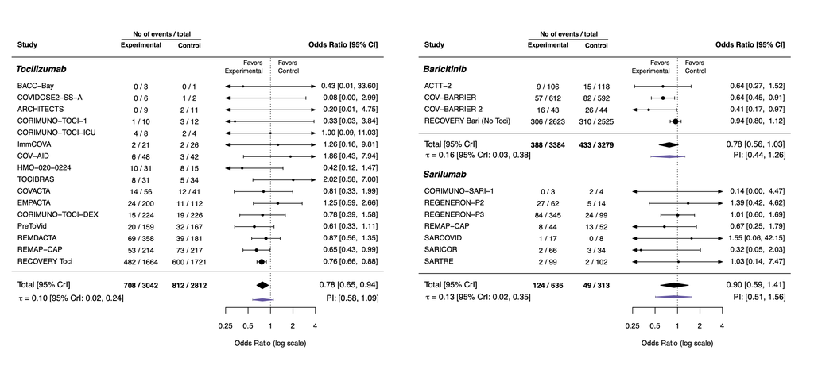

### Legend

Forest plots of Bayesian random-effect meta-analyses of tocilizumab, baricitinib, or sarilumab versus control (three separate models). Black diamonds represent median and 95% credible intervals of posterior overall results ($\mu$). Purple diamonds represent the 95% prediction intervals of posterior predictive distributions. The median and 95% credible intervals of the between-study standard deviation parameter ($\tau$) are displayed on the left bottom corner of each forest plot. Abbreviations: RE, random-effect; CrI, credible interval; PI, prediction interval.

Underlying prior distributions: average effect parameter, $\operatorname{Normal}(0, 0.75^2)$; between-study standard deviation parameter, $\operatorname{Log-Normal}(-1.975, 0.67^2)$

# Figure 3

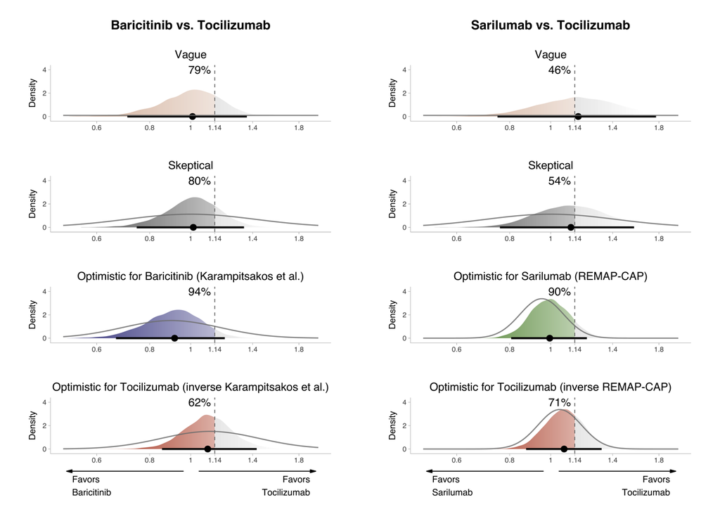

### Legend

Ratio of odds ratios between tocilizumab and baricitinib (left panel) or tocilizumab and sarilumab (right panel). Color filled curves represent the posterior distributions. Color filled areas represent the posterior probability of noninferiority (Pr < 1.14), as the percentages on top of each figure. Interval bars depict the posterior median and 95% highest density intervals. Solid gray lines represent underlying prior distributions. Each belief is labeled on top of each figure.

Underlying prior distributions for Baricitinib vs. Tocilizuamb results: “Skeptical”, $\operatorname{Normal}(0, 0.354^2)$; “Optimistic for Baricitinib”, $\operatorname{Normal}(-0.049, 0.416^2)$; “Optimistic for Tocilizumab”, $\operatorname{Normal}(0.049, 0.416^2)$; “Vague”, $\operatorname{Normal}(0, 4^2)$;

# Table 2

#### Posterior Credible Intervals and Probabilities, Meta-Regression Analyses

| Belief | ROR (95% CrI) | Probability of Noninferiority, %<sup>1</sup> | Probability of Superiority, %<sup>2</sup> |
| --- | --- | --- | --- |
| Baricitinib vs. Tocilizumab |  |  |  |
| Vague | 1.01 (0.7, 1.34) | 79 | 47 |
| Skeptical | 1.01 (0.73, 1.32) | 80 | 46 |
| Optimistic for Baricitinib (Karampitsakos et al.) | 0.92 (0.65, 1.18) | 94 | 73 |
| Optimistic for Tocilizumab (inverse Karampitsakos et al.) | 1.1 (0.83, 1.39) | 62 | 23 |
| Sarilumab vs. Tocilizumab |  |  |  |
| Vague | 1.16 (0.68, 1.73) | 46 | 25 |
| Skeptical | 1.12 (0.76, 1.57) | 54 | 28 |
| Optimistic for Sarilumab (REMAP-CAP) | 0.99 (0.81, 1.22) | 90 | 52 |
| Optimistic for Tocilizumab (inverse REMAP-CAP) | 1.08 (0.87, 1.31) | 71 | 25 |

Abbreviations: ROR, ratio of odds ratios; CrI, credible interval  
<sup>*1*</sup> Posterior probability below the noninferiority margin (1.14 ROR) <sup>*2*</sup> Posterior probability below 1.00 ROR

Underlying prior distributions for Baricitinib vs. Tocilizuamb results: “Skeptical”, $\operatorname{Normal}(0, 0.354^2)$; “Optimistic for Baricitinib”, $\operatorname{Normal}(-0.049, 0.416^2)$; “Optimistic for Tocilizumab”, $\operatorname{Normal}(0.049, 0.416^2)$; “Vague”, $\operatorname{Normal}(0, 4^2)$;